None

# Clustering Countries with the Elbow Method

When clustering data it's important to find the most optimal number of clusters. In this analysis the WCSS (Within Cluster Sum of Squares) is used to find this number of clusters. The "elbow method" is used for visualization.

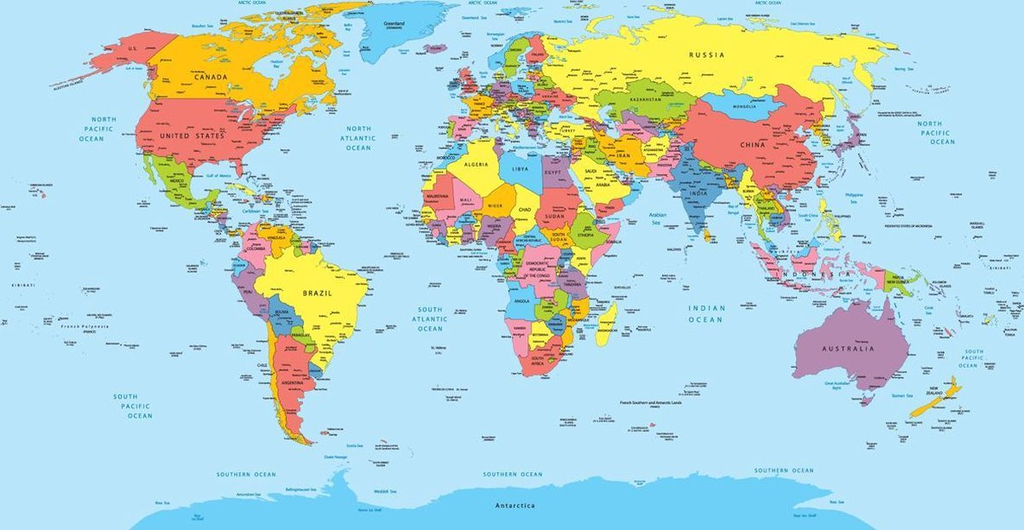

Realistic world map

### Example 1

#### What is optimal number of clusters when clustering 6 countries based on their language?

The 6 countries - in which 3 different languages are spoken - used for the first clustering.

|  | Country | Latitude | Longitude | Language |
| --- | --- | --- | --- | --- |
| 0 | USA | 44.97 | -103.77 | English |
| 1 | Canada | 62.40 | -96.80 | English |
| 2 | France | 46.75 | 2.40 | French |
| 3 | UK | 54.01 | -2.53 | English |
| 4 | Germany | 51.15 | 10.40 | German |
| 5 | Australia | -25.45 | 133.11 | English |

In this table the languages are converted to a number.

|  | Country | Latitude | Longitude | Language |
| --- | --- | --- | --- | --- |
| 0 | USA | 44.97 | -103.77 | 0 |
| 1 | Canada | 62.40 | -96.80 | 0 |
| 2 | France | 46.75 | 2.40 | 1 |
| 3 | UK | 54.01 | -2.53 | 0 |
| 4 | Germany | 51.15 | 10.40 | 2 |
| 5 | Australia | -25.45 | 133.11 | 0 |

The six countries grouped by their latitude and longitude. Their location corresponds with the world map at the top.

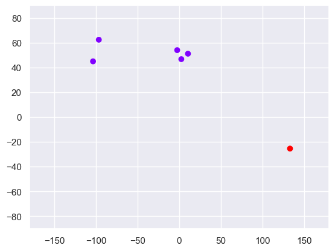

The Elbow Method

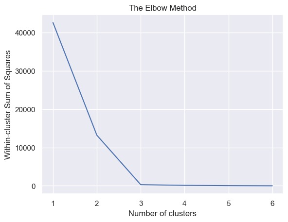

As expected, this plot shows that for this example 3 is the optimal number of clusters. The WCSS is as low as possible as well as the number of clusters.

### Example 2

In this example WCSS is used to determine the optimal number of clusters when clustering all countries in the world based on the latitude and longitude of each country.

The latitude and longitude of all countries (only part of it is shown).

[output not shown]

Table of countries with their latitude and longitude and the cluster in which they are classified.

|  | latitude | longitude | cluster |
| --- | --- | --- | --- |
| 0 | 42.55 | 1.60 | 4 |
| 1 | 23.42 | 53.85 | 0 |
| 2 | 33.94 | 67.71 | 0 |
| 3 | 17.06 | -61.80 | 2 |
| 4 | 18.22 | -63.07 | 2 |
| ... | ... | ... | ... |
| 239 | 15.55 | 48.52 | 0 |
| 240 | -12.83 | 45.17 | 0 |
| 241 | -30.56 | 22.94 | 4 |
| 242 | -13.13 | 27.85 | 0 |
| 243 | -19.02 | 29.15 | 0 |

244 rows × 3 columns

Countries clustered by their latitude and longitude, resulting in clusters per continent. The resulting shape looks like a world map.

```
<function matplotlib.pyplot.show(close=None, block=None)>
```

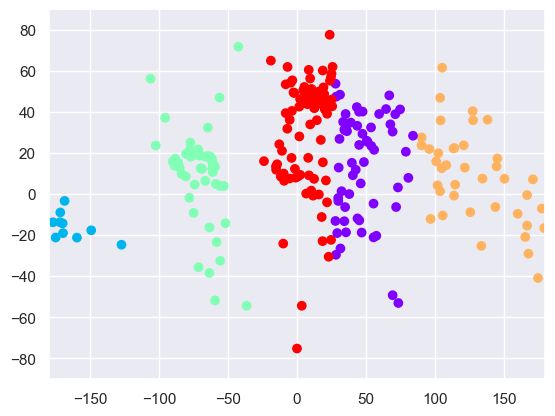

The plot resulting from using the WCSS looks like an elbow.

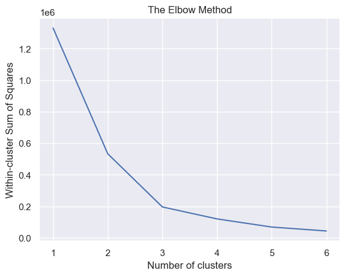

```python
number_clusters_2 = range(1,7)
plt.plot(number_clusters, wcss)
plt.title('The Elbow Method')
plt.xlabel('Number of clusters')
plt.ylabel('Within-cluster Sum of Squares')
```